# Part II - Effects of user types, member gender and day on duration of bike sharing

## by Egbebuike Emmanuel

## Investigation Overview

In this investigation, I explored the effects of some variables on the length of the bike sharing. Of particular interest were te user type (customer or subscriber) and then the day of the week. THe effect of the gender on duration would be shown.

## Dataset Overview

The dataset consists of about 184,000. To use this data, I had to clean up the dataset. This involved changing column data types and extracting the day and day hour from the dataset. I dropped rows having null values and i removes the gps data of the start and end locations. This reduced the rows to about 175,000. Further into the analysis, I used the log of the duration_sec to provide better analysis and visualization.

## Distribution of the duration

The duration(seconds) has most of the datapoints (over 97%) below the 2000 sec mark. It has a unimodal distribution when plotted on a log scale. The mode is around 500 seconds.

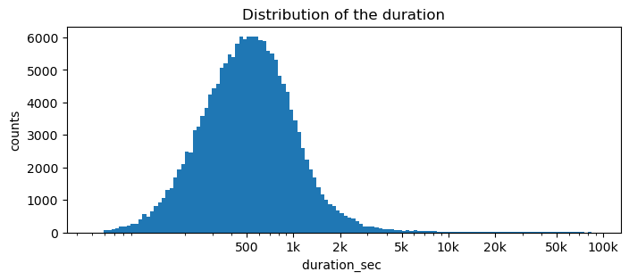

## Distribution and mean duration of customers and subscribers

We can see that the subscribers far outnumbers the customers. Furthermore, there are no customers who use the bike share for all trips. While the subscribers are more than the customers, the average duration of customers far exceeds that of subscribers.

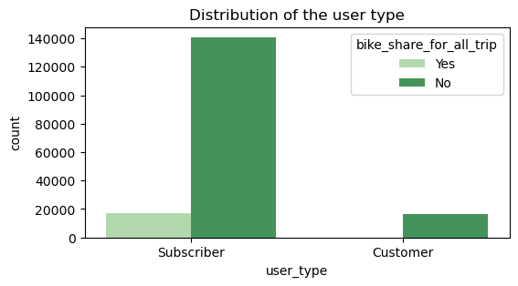

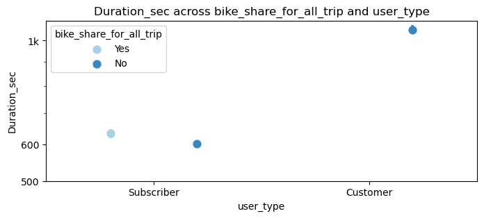

## Duration variance across the day of the week

We see thar the weekends, while technically having the least number of bikeshare, boasts of days with the longest durations. In the second plot, you will see how sat and sun tapers off into the higher duration range. You would also see that the weekends is mostly active in the day, having a mono modal distribution, unlike the weekdays.

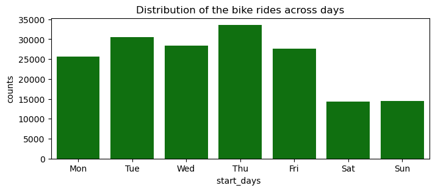

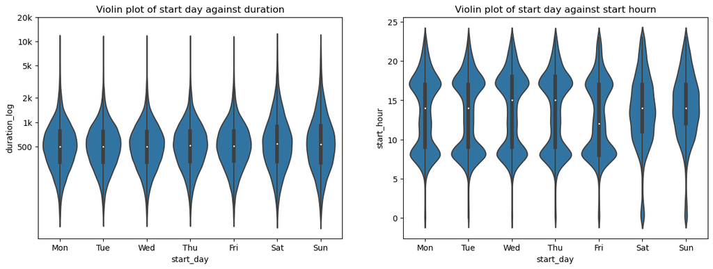

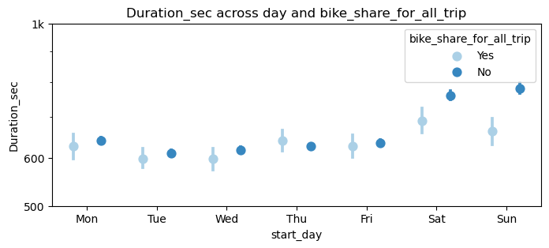

## Member gender versus the duration

Females have marginally longer duration than. This nis evident across all days of the week. The figures below says all

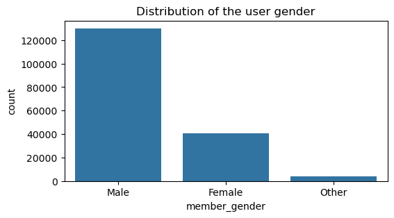

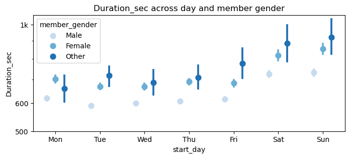